# Relationships among Personality Traits by Damian Satterthwaite-Phillips

The following analyses were done on personality trait data from: http://personality-testing.info/_rawdata/ (fourth row of the table) …sometimes known as the “BIG 5.” The personality traits tested here are: E: Extroversion; N: Nervousness or Neuroticness; A: Affinity or Empathy; C: Conscientiousness; and O: Cognitive/Imaginative. Each of these categories had 10 different questions that asked respondents to reply with a 1 - 5 value (1 = strongly disagree, 5 = strongly agree). Additional variables included gender, age, race, handedness, country, whether or not the respondent was a native speaker of English, and the source from which the respondent was directed to the test (e.g., Facebook, Google, academic institution, etc.). These should be self-explanatory, but for further information see the link provided above.

In the following analyses, the relationships between personality traits, gender, age, race, handedness, and a few other variables are explored. Cleaning and recoding of the data are both explained in greater detail below.

### Setup

```r
# I have the habit of clearing everything from memory when working on a new script.
# Warning: this code will erase all objects in working memory.
rm(list = ls())
options(warn = -1) # Suppresses warning messages to make final html file nicer... be sure to set back
                   # to 0 at the end of the script!
```

```r
library(GGally)
library(ggplot2)
library(scales)
```

# Analysis

### Load the Data

```r
# Change path to directory as needed...
big5 <- read.csv('~/Desktop/Classes/Udacity/EDA_withR/Project/BIG5/data.csv', sep='\t')

# Check out the data:
names(big5)
```

```
##  [1] "race"    "age"     "engnat"  "gender"  "hand"    "source"  "country"
##  [8] "E1"      "E2"      "E3"      "E4"      "E5"      "E6"      "E7"
## [15] "E8"      "E9"      "E10"     "N1"      "N2"      "N3"      "N4"
## [22] "N5"      "N6"      "N7"      "N8"      "N9"      "N10"     "A1"
## [29] "A2"      "A3"      "A4"      "A5"      "A6"      "A7"      "A8"
## [36] "A9"      "A10"     "C1"      "C2"      "C3"      "C4"      "C5"
## [43] "C6"      "C7"      "C8"      "C9"      "C10"     "O1"      "O2"
## [50] "O3"      "O4"      "O5"      "O6"      "O7"      "O8"      "O9"
## [57] "O10"
```

```r
# str(big5) # Not shown here.
```

### Data Cleaning and Prep

A fair amount of data cleaning needs to be done before analysis can begin.

```r
# For all columns a score of 0 indicates 'NA' ...change:
big5[big5 == 0] <- NA

# There are 5 main personality traits being examined-- group them:
# "E" columns ('extroversion')
E <- 8:17

# "N" columns ('nervousness')
N <- 18:27

# "A" columns ('affinity' or 'empathy')
A <- 28:37

# "C" columns ('conscientiousness')
C <- 38:47

# "O" columns ('cognition')
O <- 48:57

# The scoring is inconsistent.. for example for the 'extroversion' category, sometimes a 5 ('strongly
# agree) is the most extroverted ('I am the life of the party'), and sometimes a 5 is the least
# extroverted ('I have little to say').  If we flip the scoring for some columns, then the measurements
# will be consistent (e.g., 5 always represents the "most..." {extroverted, nervouse, empathetic...})
reversed <- c( 'E2', 'E4', 'E6', 'E8', 'E10', 'N2', 'N4', 'A1', 'A3','A5','A7','C2','C4','C6','C8',
               'O2', 'O4','O6' )

# check the original scores in those columns
head(big5[,reversed])
```

```
##   E2 E4 E6 E8 E10 N2 N4 A1 A3 A5 A7 C2 C4 C6 C8 O2 O4 O6
## 1  2  2  1  3   1  5  5  1  1  2  1  1  1  1  1  1  1  1
## 2  2  3  3  5   5  3  2  1  3  4  2  1  2  1  1  3  3  3
## 3  1  4  1  5   1  1  5  5  5  1  1  1  1  1  1  5  1  1
## 4  5  4  4  4   5  4  2  2  4  3  3  3  5  4  4  3  2  2
## 5  1  3  1  1   5  3  4  5  3  1  1  1  3  1  3  1  1  1
## 6  5  4  3  4   5  5  5  2  3  3  3  5  3  4  3  2  3  5
```

```r
# Now reverse them
big5[, reversed] <- 6 - big5[reversed]

# And compare...
head(big5[,reversed])
```

```
##   E2 E4 E6 E8 E10 N2 N4 A1 A3 A5 A7 C2 C4 C6 C8 O2 O4 O6
## 1  4  4  5  3   5  1  1  5  5  4  5  5  5  5  5  5  5  5
## 2  4  3  3  1   1  3  4  5  3  2  4  5  4  5  5  3  3  3
## 3  5  2  5  1   5  5  1  1  1  5  5  5  5  5  5  1  5  5
## 4  1  2  2  2   1  2  4  4  2  3  3  3  1  2  2  3  4  4
## 5  5  3  5  5   1  3  2  1  3  5  5  5  3  5  3  5  5  5
## 6  1  2  3  2   1  1  1  4  3  3  3  1  3  2  3  4  3  1
```

```r
# Now we can create "overall" scores for each category by summing the individual columns:
big5$EScore <- rowSums(big5[, E], na.rm=T)
big5$NScore <- rowSums(big5[, N], na.rm=T)
big5$AScore <- rowSums(big5[, A], na.rm=T)
big5$CScore <- rowSums(big5[, C], na.rm=T)
big5$OScore <- rowSums(big5[, O], na.rm=T)

# Check:
head(cbind(big5[, E], big5$EScore)) # sums look good!
```

```
##   E1 E2 E3 E4 E5 E6 E7 E8 E9 E10 big5$EScore
## 1  4  4  5  4  5  5  4  3  5   5          44
## 2  2  4  3  3  3  3  1  1  1   1          22
## 3  5  5  1  2  5  5  1  1  5   5          35
## 4  2  1  2  2  3  2  3  2  4   1          22
## 5  3  5  3  3  3  5  3  5  3   1          34
## 6  1  1  2  2  1  3  2  2  1   1          16
```

```r
# ...but remember there may be some values missing (NA), in which case we will have to adjust the
# scores
summary(big5)
```

```
##       race             age                engnat         gender
##  Min.   : 1.000   Min.   :       13   Min.   :1.00   Min.   :1.000
##  1st Qu.: 3.000   1st Qu.:       18   1st Qu.:1.00   1st Qu.:1.000
##  Median : 3.000   Median :       22   Median :1.00   Median :2.000
##  Mean   : 5.366   Mean   :    50767   Mean   :1.37   Mean   :1.619
##  3rd Qu.: 9.000   3rd Qu.:       31   3rd Qu.:2.00   3rd Qu.:2.000
##  Max.   :13.000   Max.   :999999999   Max.   :2.00   Max.   :3.000
##  NA's   :153                          NA's   :70     NA's   :24
##       hand           source         country           E1
##  Min.   :1.000   Min.   :1.000   US     :8753   Min.   :1.000
##  1st Qu.:1.000   1st Qu.:1.000   GB     :1531   1st Qu.:2.000
##  Median :1.000   Median :1.000   IN     :1464   Median :3.000
##  Mean   :1.136   Mean   :1.952   AU     : 974   Mean   :2.629
##  3rd Qu.:1.000   3rd Qu.:2.000   CA     : 924   3rd Qu.:4.000
##  Max.   :3.000   Max.   :5.000   (Other):6065   Max.   :5.000
##  NA's   :100                     NA's   :   8   NA's   :1
##        E2             E3              E4              E5
##  Min.   :1.00   Min.   :1.000   Min.   :1.000   Min.   :1.000
##  1st Qu.:2.00   1st Qu.:3.000   1st Qu.:2.000   1st Qu.:2.000
##  Median :3.00   Median :4.000   Median :3.000   Median :4.000
##  Mean   :3.24   Mean   :3.417   Mean   :2.848   Mean   :3.432
##  3rd Qu.:4.00   3rd Qu.:4.000   3rd Qu.:4.000   3rd Qu.:5.000
##  Max.   :5.00   Max.   :5.000   Max.   :5.000   Max.   :5.000
##  NA's   :1      NA's   :1       NA's   :1       NA's   :1
##        E6              E7              E8              E9
##  Min.   :1.000   Min.   :1.000   Min.   :1.000   Min.   :1.000
##  1st Qu.:3.000   1st Qu.:2.000   1st Qu.:2.000   1st Qu.:2.000
##  Median :4.000   Median :3.000   Median :3.000   Median :3.000
##  Mean   :3.547   Mean   :2.867   Mean   :2.623   Mean   :3.094
##  3rd Qu.:5.000   3rd Qu.:4.000   3rd Qu.:4.000   3rd Qu.:4.000
##  Max.   :5.000   Max.   :5.000   Max.   :5.000   Max.   :5.000
##  NA's   :1       NA's   :1       NA's   :1       NA's   :1
##       E10              N1              N2              N3
##  Min.   :1.000   Min.   :1.000   Min.   :1.000   Min.   :1.000
##  1st Qu.:1.000   1st Qu.:2.000   1st Qu.:2.000   1st Qu.:3.000
##  Median :2.000   Median :3.000   Median :3.000   Median :4.000
##  Mean   :2.414   Mean   :3.262   Mean   :2.765   Mean   :3.843
##  3rd Qu.:3.000   3rd Qu.:4.000   3rd Qu.:4.000   3rd Qu.:5.000
##  Max.   :5.000   Max.   :5.000   Max.   :5.000   Max.   :5.000
##  NA's   :1       NA's   :1       NA's   :1       NA's   :1
```

[output cut: 73 more lines]

```
##  Min.   :1.000   Min.   : 0.00   Min.   : 0.00   Min.   : 0.00
##  1st Qu.:3.000   1st Qu.:23.00   1st Qu.:25.00   1st Qu.:34.00
##  Median :4.000   Median :30.00   Median :31.00   Median :39.00
##  Mean   :4.005   Mean   :30.11   Mean   :30.97   Mean   :38.44
##  3rd Qu.:5.000   3rd Qu.:37.00   3rd Qu.:37.00   3rd Qu.:44.00
##  Max.   :5.000   Max.   :50.00   Max.   :50.00   Max.   :50.00
##  NA's   :1
##      CScore          OScore
##  Min.   : 0.00   Min.   : 0.00
##  1st Qu.:28.00   1st Qu.:35.00
##  Median :34.00   Median :40.00
##  Mean   :33.47   Mean   :39.09
##  3rd Qu.:39.00   3rd Qu.:44.00
##  Max.   :50.00   Max.   :50.00
##
```

```r
# We see there is just 1 NA value in most columns... could it all be a single row?
which(is.na(big5$O5))
```

```
## [1] 19065
```

```r
# Indicates that the NA is in row 19065-- examine this row:
big5[19065, ]
```

```
##       race age engnat gender hand source country E1 E2 E3 E4 E5 E6 E7 E8
## 19065   13  52      2      2    1      2      IN NA NA NA NA NA NA NA NA
##       E9 E10 N1 N2 N3 N4 N5 N6 N7 N8 N9 N10 A1 A2 A3 A4 A5 A6 A7 A8 A9 A10
## 19065 NA  NA NA NA NA NA NA NA NA NA NA  NA NA NA NA NA NA NA NA NA NA  NA
##       C1 C2 C3 C4 C5 C6 C7 C8 C9 C10 O1 O2 O3 O4 O5 O6 O7 O8 O9 O10 EScore
## 19065 NA NA NA NA NA NA NA NA NA  NA NA NA NA NA NA NA NA NA NA  NA      0
##       NScore AScore CScore OScore
## 19065      0      0      0      0
```

```r
# Indeed, all personality scores are 'NA' ... let's just remove this useless datum
big5 <- big5[-19065, ]

# And now...
summary(big5) # ... no more missing data in the personality variables
```

```
##       race             age                engnat         gender
##  Min.   : 1.000   Min.   :       13   Min.   :1.00   Min.   :1.000
##  1st Qu.: 3.000   1st Qu.:       18   1st Qu.:1.00   1st Qu.:1.000
##  Median : 3.000   Median :       22   Median :1.00   Median :2.000
##  Mean   : 5.365   Mean   :    50770   Mean   :1.37   Mean   :1.619
##  3rd Qu.: 9.000   3rd Qu.:       31   3rd Qu.:2.00   3rd Qu.:2.000
##  Max.   :13.000   Max.   :999999999   Max.   :2.00   Max.   :3.000
##  NA's   :153                          NA's   :70     NA's   :24
##       hand           source         country           E1
##  Min.   :1.000   Min.   :1.000   US     :8753   Min.   :1.000
##  1st Qu.:1.000   1st Qu.:1.000   GB     :1531   1st Qu.:2.000
##  Median :1.000   Median :1.000   IN     :1463   Median :3.000
##  Mean   :1.136   Mean   :1.952   AU     : 974   Mean   :2.629
##  3rd Qu.:1.000   3rd Qu.:2.000   CA     : 924   3rd Qu.:4.000
##  Max.   :3.000   Max.   :5.000   (Other):6065   Max.   :5.000
##  NA's   :100                     NA's   :   8
##        E2             E3              E4              E5
##  Min.   :1.00   Min.   :1.000   Min.   :1.000   Min.   :1.000
##  1st Qu.:2.00   1st Qu.:3.000   1st Qu.:2.000   1st Qu.:2.000
##  Median :3.00   Median :4.000   Median :3.000   Median :4.000
##  Mean   :3.24   Mean   :3.417   Mean   :2.848   Mean   :3.432
##  3rd Qu.:4.00   3rd Qu.:4.000   3rd Qu.:4.000   3rd Qu.:5.000
##  Max.   :5.00   Max.   :5.000   Max.   :5.000   Max.   :5.000
##
##        E6              E7              E8              E9
##  Min.   :1.000   Min.   :1.000   Min.   :1.000   Min.   :1.000
##  1st Qu.:3.000   1st Qu.:2.000   1st Qu.:2.000   1st Qu.:2.000
##  Median :4.000   Median :3.000   Median :3.000   Median :3.000
##  Mean   :3.547   Mean   :2.867   Mean   :2.623   Mean   :3.094
##  3rd Qu.:5.000   3rd Qu.:4.000   3rd Qu.:4.000   3rd Qu.:4.000
##  Max.   :5.000   Max.   :5.000   Max.   :5.000   Max.   :5.000
##
##       E10              N1              N2              N3
##  Min.   :1.000   Min.   :1.000   Min.   :1.000   Min.   :1.000
##  1st Qu.:1.000   1st Qu.:2.000   1st Qu.:2.000   1st Qu.:3.000
##  Median :2.000   Median :3.000   Median :3.000   Median :4.000
##  Mean   :2.414   Mean   :3.262   Mean   :2.765   Mean   :3.843
##  3rd Qu.:3.000   3rd Qu.:4.000   3rd Qu.:4.000   3rd Qu.:5.000
##  Max.   :5.000   Max.   :5.000   Max.   :5.000   Max.   :5.000
##
```

[output cut: 73 more lines]

```
##  Min.   :1.000   Min.   :10.00   Min.   :10.00   Min.   :10.00
##  1st Qu.:3.000   1st Qu.:23.00   1st Qu.:25.00   1st Qu.:34.00
##  Median :4.000   Median :30.00   Median :31.00   Median :39.00
##  Mean   :4.005   Mean   :30.11   Mean   :30.97   Mean   :38.45
##  3rd Qu.:5.000   3rd Qu.:37.00   3rd Qu.:37.00   3rd Qu.:44.00
##  Max.   :5.000   Max.   :50.00   Max.   :50.00   Max.   :50.00
##
##      CScore          OScore
##  Min.   :10.00   Min.   :10.00
##  1st Qu.:28.00   1st Qu.:35.00
##  Median :34.00   Median :40.00
##  Mean   :33.47   Mean   :39.09
##  3rd Qu.:39.00   3rd Qu.:44.00
##  Max.   :50.00   Max.   :50.00
##
```

```r
# Clean the remaining variables:
# The variable "race" is a categorical variable with numerical value codings; change class and label
big5$race <- as.factor(big5$race)
levels(big5$race) <- c('Mixed', 'Arctic', 'European', 'Indian', 'MidEastern', 'NAfrican',
                       'AustrNative', 'NatAmerican', 'NEAsian', 'Pacific', 'SEAsian', 'WAfrican',
                       'Other')

# The variable "engnat" (native speaker of English?) is also categorical; convert
big5$engnat <- as.factor(big5$engnat)
levels(big5$engnat) <- c('yes', 'no')

# ...same with the variable "gender"
big5$gender <- as.factor(big5$gender)
levels(big5$gender) <- c('male', 'female', 'other')

# ...same with "hand" (handedness)
big5$hand <- as.factor(big5$hand)
levels(big5$hand) <- c('right', 'left', 'ambi')

# ...and same with "source"
big5$source <- as.factor(big5$source)
levels(big5$source) <- c('otherPage', 'Google', 'Facebook', 'Edu', 'other')

# Check data again:
summary(big5)
```

```
##        race            age             engnat         gender
##  European:10537   Min.   :       13   yes :12379   male  : 7608
##  Other   : 2552   1st Qu.:       18   no  : 7269   female:11984
##  SEAsian : 1861   Median :       22   NA's:   70   other :  102
##  Indian  : 1518   Mean   :    50770                NA's  :   24
##  Mixed   : 1434   3rd Qu.:       31
##  (Other) : 1663   Max.   :999999999
##  NA's    :  153
##     hand             source         country           E1
##  right:17423   otherPage:12099   US     :8753   Min.   :1.000
##  left : 1724   Google   : 3652   GB     :1531   1st Qu.:2.000
##  ambi :  471   Facebook :  303   IN     :1463   Median :3.000
##  NA's :  100   Edu      :  137   AU     : 974   Mean   :2.629
##                other    : 3527   CA     : 924   3rd Qu.:4.000
##                                  (Other):6065   Max.   :5.000
##                                  NA's   :   8
##        E2             E3              E4              E5
##  Min.   :1.00   Min.   :1.000   Min.   :1.000   Min.   :1.000
##  1st Qu.:2.00   1st Qu.:3.000   1st Qu.:2.000   1st Qu.:2.000
##  Median :3.00   Median :4.000   Median :3.000   Median :4.000
##  Mean   :3.24   Mean   :3.417   Mean   :2.848   Mean   :3.432
##  3rd Qu.:4.00   3rd Qu.:4.000   3rd Qu.:4.000   3rd Qu.:5.000
##  Max.   :5.00   Max.   :5.000   Max.   :5.000   Max.   :5.000
##
##        E6              E7              E8              E9
##  Min.   :1.000   Min.   :1.000   Min.   :1.000   Min.   :1.000
##  1st Qu.:3.000   1st Qu.:2.000   1st Qu.:2.000   1st Qu.:2.000
##  Median :4.000   Median :3.000   Median :3.000   Median :3.000
##  Mean   :3.547   Mean   :2.867   Mean   :2.623   Mean   :3.094
##  3rd Qu.:5.000   3rd Qu.:4.000   3rd Qu.:4.000   3rd Qu.:4.000
##  Max.   :5.000   Max.   :5.000   Max.   :5.000   Max.   :5.000
##
##       E10              N1              N2              N3
##  Min.   :1.000   Min.   :1.000   Min.   :1.000   Min.   :1.000
##  1st Qu.:1.000   1st Qu.:2.000   1st Qu.:2.000   1st Qu.:3.000
##  Median :2.000   Median :3.000   Median :3.000   Median :4.000
##  Mean   :2.414   Mean   :3.262   Mean   :2.765   Mean   :3.843
##  3rd Qu.:3.000   3rd Qu.:4.000   3rd Qu.:4.000   3rd Qu.:5.000
##  Max.   :5.000   Max.   :5.000   Max.   :5.000   Max.   :5.000
##
```

[output cut: 73 more lines]

```
##  Min.   :1.000   Min.   :10.00   Min.   :10.00   Min.   :10.00
##  1st Qu.:3.000   1st Qu.:23.00   1st Qu.:25.00   1st Qu.:34.00
##  Median :4.000   Median :30.00   Median :31.00   Median :39.00
##  Mean   :4.005   Mean   :30.11   Mean   :30.97   Mean   :38.45
##  3rd Qu.:5.000   3rd Qu.:37.00   3rd Qu.:37.00   3rd Qu.:44.00
##  Max.   :5.000   Max.   :50.00   Max.   :50.00   Max.   :50.00
##
##      CScore          OScore
##  Min.   :10.00   Min.   :10.00
##  1st Qu.:28.00   1st Qu.:35.00
##  Median :34.00   Median :40.00
##  Mean   :33.47   Mean   :39.09
##  3rd Qu.:39.00   3rd Qu.:44.00
##  Max.   :50.00   Max.   :50.00
##
```

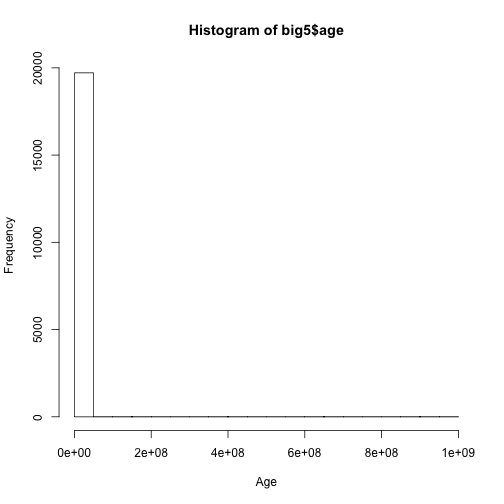

```r
# At a glance, most variables look ok, except that there are some clearly problematic data in the
# "age" variable (Max == 999999999)... examine the age distribution more closely:
hist(big5$age, xlab='Age')
```

```r
# Ok, not very useful....
table(big5$age > 100)
```

```
##
## FALSE  TRUE
## 19635    83
```

```r
# It looks like 83 people claim to be more than 100... let's take a closer look at those values
sort(big5$age, decreasing = T)[1:100]
```

```
##   [1] 999999999    412434      2000      1999      1998      1998      1998
##   [8]      1998      1997      1997      1997      1997      1996      1996
##  [15]      1996      1996      1996      1996      1996      1995      1995
##  [22]      1995      1995      1995      1994      1994      1994      1994
##  [29]      1994      1994      1994      1994      1993      1993      1993
##  [36]      1993      1993      1992      1992      1992      1992      1992
##  [43]      1992      1992      1992      1992      1991      1991      1991
##  [50]      1990      1990      1990      1989      1989      1989      1989
##  [57]      1989      1988      1986      1986      1985      1985      1984
##  [64]      1984      1982      1982      1982      1982      1977      1976
##  [71]      1976      1974      1968      1964      1961       266       223
##  [78]       211       208       191       188       188       118       100
##  [85]        99        97        92        80        79        79        78
##  [92]        77        77        77        76        76        75        75
##  [99]        75        75
```

```r
# It seems that, in a number of these cases, the respondent entered their year of birth rather than
# their age, but to err on the side of caution, lets replace all ages > 100 with NA:
big5$age[big5$age > 100] <- NA
```

## Preliminary Investigation (Individual Variables)

Now that we have a reasonably clean data set, examine pairs– to minimize the number of variables, use summed scores for each of the “big 5” personality components, and omit 'country':

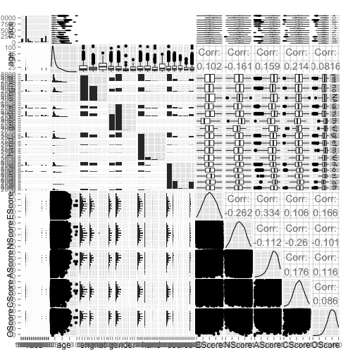

```r
pairData <- c(1:6, 58:62)
ggpairs(big5[pairData])
```

There are a number of interesting observations here already… lets consider a few, row by row:

```r
# Race:  evidentally data are not evenly distributed among races and one value is especially high:
table(big5$race)  # [Caucasians of] European descent are the largest group by far
```

```
##
##       Mixed      Arctic    European      Indian  MidEastern    NAfrican
##        1434          14       10537        1518         515         397
## AustrNative NatAmerican     NEAsian     Pacific     SEAsian    WAfrican
##          24         201         188          65        1861         259
##       Other
##        2552
```

```r
# Age is a long-tailed distribution: most respondents are relatively young:
quantile(big5$age, probs=seq(0, 1, 0.1), na.rm=T)
```

```
##   0%  10%  20%  30%  40%  50%  60%  70%  80%  90% 100%
##   13   16   17   19   20   22   25   28   34   44  100
```

```r
# Half the respondents are age 13 - 22; 90% are 44 or under
# Age correlates most strongly with "C" score-- older people are more likely to be more conscientious
# Gender: more female respondents than male:
table(big5$gender)
```

```
##
##   male female  other
##   7608  11984    102
```

```r
table(big5$gender) / sum(table(big5$gender)) # appx. 61% female
```

```
##
##        male      female       other
## 0.386310551 0.608510206 0.005179242
```

```r
# There are some interesting gender-based variations in personality traits... to be explored further
# Handedness: righties dominate (unsurprisingly):
table(big5$hand)
```

```
##
## right  left  ambi
## 17423  1724   471
```

```r
table(big5$hand) / sum(table(big5$hand)) # appx. 89% right-handed
```

```
##
##      right       left       ambi
## 0.88811296 0.08787848 0.02400856
```

```r
# No easily observable difference in personality based on handedness
```

Personality traits: The scatterplots are all too overplotted to make much sense of in this graphic, so we'll return to those later. Interestingly, 'extroversion (E)', 'nervousness (N)', and 'conscientiousness ©' all appear to be roughly normal, whereas both 'affinity (A)' and 'cognitive (O)' are both left-skewed, which also seems to be a good thing: there are more empathetic people than non-empathetic, and more cognitive/imagintive people than not… or at least that's how people think of themselves.

Now let's examine some of these in more detail:

### Race

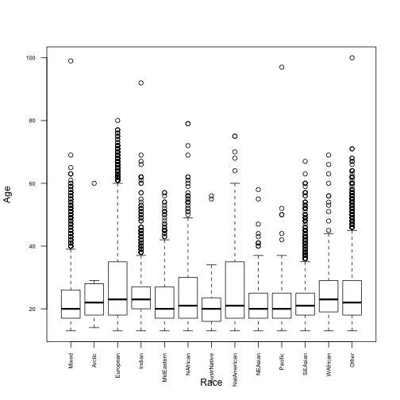

```r
plot(age ~ race, data=big5, las=2, cex.axis=0.6, xlab='Race', ylab='Age')
```

```r
tapply(big5$age, big5$race, summary, na.rm=T)
```

```
## $Mixed
##    Min. 1st Qu.  Median    Mean 3rd Qu.    Max.    NA's
##   13.00   17.00   20.00   23.69   26.00   99.00       4
##
## $Arctic
##    Min. 1st Qu.  Median    Mean 3rd Qu.    Max.    NA's
##   14.00   18.00   22.00   24.62   28.00   60.00       1
##
## $European
##    Min. 1st Qu.  Median    Mean 3rd Qu.    Max.    NA's
##   13.00   18.00   23.00   27.93   35.00   80.00       8
##
## $Indian
##    Min. 1st Qu.  Median    Mean 3rd Qu.    Max.    NA's
##   13.00   20.00   23.00   24.74   27.00   92.00      13
##
## $MidEastern
##    Min. 1st Qu.  Median    Mean 3rd Qu.    Max.    NA's
##    13.0    17.0    20.0    23.4    27.0    57.0       9
##
## $NAfrican
##    Min. 1st Qu.  Median    Mean 3rd Qu.    Max.    NA's
##   13.00   17.00   21.00   25.53   30.00   79.00       1
##
## $AustrNative
##    Min. 1st Qu.  Median    Mean 3rd Qu.    Max.
##   13.00   16.00   20.00   23.12   23.25   56.00
##
## $NatAmerican
##    Min. 1st Qu.  Median    Mean 3rd Qu.    Max.
##   13.00   17.00   21.00   27.65   35.00   75.00
##
## $NEAsian
##    Min. 1st Qu.  Median    Mean 3rd Qu.    Max.    NA's
##   13.00   17.00   20.00   22.32   25.00   58.00       1
##
## $Pacific
##    Min. 1st Qu.  Median    Mean 3rd Qu.    Max.
##   13.00   17.00   20.00   23.75   25.00   97.00
##
## $SEAsian
##    Min. 1st Qu.  Median    Mean 3rd Qu.    Max.    NA's
##   13.00   18.00   21.00   22.51   25.00   67.00      26
##
## $WAfrican
##    Min. 1st Qu.  Median    Mean 3rd Qu.    Max.
##   13.00   19.00   23.00   25.39   29.00   69.00
##
## $Other
##    Min. 1st Qu.  Median    Mean 3rd Qu.    Max.    NA's
##   13.00   18.00   22.00   25.48   29.00  100.00      19
```

```r
# While median and lower quantile ages are similar for most groups, respondents that were European, N.
# African, and Native American had larger IQRs with the 3rd quantile being older than in other groups.

table(big5$race, big5$gender)
```

```
##
##               male female other
##   Mixed        515    902    15
##   Arctic         8      5     1
##   European    4128   6341    55
##   Indian       835    679     2
##   MidEastern   198    317     0
##   NAfrican     147    250     0
##   AustrNative   10     12     2
##   NatAmerican   75    123     3
##   NEAsian       71    115     2
##   Pacific       24     41     0
##   SEAsian      622   1229     8
##   WAfrican     119    139     1
##   Other        817   1720    13
```

```r
# convert to proportions:
round(table(big5$race, big5$gender) / rowSums(table(big5$race, big5$gender)), 3)
```

```
##
##                male female other
##   Mixed       0.360  0.630 0.010
##   Arctic      0.571  0.357 0.071
##   European    0.392  0.603 0.005
##   Indian      0.551  0.448 0.001
##   MidEastern  0.384  0.616 0.000
##   NAfrican    0.370  0.630 0.000
##   AustrNative 0.417  0.500 0.083
##   NatAmerican 0.373  0.612 0.015
##   NEAsian     0.378  0.612 0.011
##   Pacific     0.369  0.631 0.000
##   SEAsian     0.335  0.661 0.004
##   WAfrican    0.459  0.537 0.004
##   Other       0.320  0.675 0.005
```

```r
# In most ethnic groups, more females responded than males.  The reverse in true in the Arctic, and
# Indians and W. Africans were closest to 50/50.  Also of note, Arctic and Australian Native peoples
# had the highest incidence of people identifying as "other" gender.
```

### Age

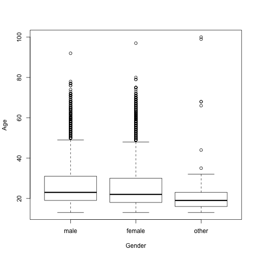

```r
plot(age ~ gender, data=big5, xlab='Gender', ylab='Age')
```

```r
# Age distributions between male and female are similar... 'other' tends to be younger overall...
# there are multiple possible interpretations:  younger people may be more uncertain about their
# gender; they may be more open to questioning; or they may be more likely to falsify their
# responses
```

### Gender

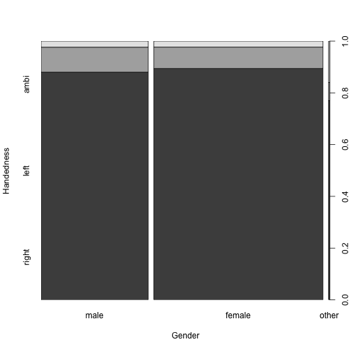

```r
plot(hand ~ gender, data=big5, xlab='Gender', ylab='Handedness')
```

```r
# Males and females show similar proportions of left- and right-handers; interestingly, people
# identifying as 'other' gender, had higher proportions of ambidextrous people, though this may also
# be a result of people being dishonest or joking about gender also being more likely to be dishonest
# or joke about handedness
```

## Personality Traits

Now onto the main categories of interest: personality traits

```r
personality <- 58:62
round(cor(big5[personality]), 3)
```

```
##        EScore NScore AScore CScore OScore
## EScore  1.000 -0.262  0.334  0.106  0.166
## NScore -0.262  1.000 -0.112 -0.260 -0.101
## AScore  0.334 -0.112  1.000  0.176  0.116
## CScore  0.106 -0.260  0.176  1.000  0.086
## OScore  0.166 -0.101  0.116  0.086  1.000
```

```r
# Interestingly, all of the personality traits are fairly weakly correlated with each other.  The
# strongest correlation is between extroversion and affinity: more extroverted people tend to be more
# empathetic (or at least view themselves as such).
```